# Fit univariate Bayesian SITAR model

Satpal Sandhu

January 25, 2024

# 1 Introduction

The super imposition by translation and rotation (*SITAR*) model is a shape-invariant nonlinear mixed effect growth curve model that fits a population average curve to the data, and aligns each individual’s growth trajectory to this underlying population average curve via a set of random effects (T. J. Cole et al., 2010). The ‘bsitar’ package (Sandhu, 2023) implements Bayesian estimation of the *SITAR* model and can fit a *univariate* model (analysis of a single outcome), *univariate_by* model (analysis of a single outcome separately for sub groups defined by a factor variable such as gender), and *multivariate model* (joint modelling of two or more outcomes). A detailed introduction to the Bayesian *SITAR* model including biological and mathematical description of the model, Markov chain Monte Carlo (MCMC) estimation, and the priors specifications are provided in the the Bayesian SITAR - An Introduction vignette.

In this vignette, we fit *univariate* Bayesian *SITAR* model using ‘bsitar’ package (Sandhu, 2023) and compare findings with the results of non Bayesian *SITAR* model (fit via the ‘sitar’ package (T. Cole, 2022)). Hereafter, the Bayesian and non Bayesian model estimated by the ‘sitar’ and ‘bsitar’ package are referred to as **sitar** and **bsitar** models, respectively. The purpose is to demonstrate that both ‘sitar’ and ‘bsitar’ packages perform similarly in estimating population average and individual specific trajectories and growth spurt parameters (timing and the intensity). The aim of this exercise is to ensure that our ‘bsitar’ package performs as expected (i.e., no systematic difference in results when compared with the *sitar* model) before we fit more complex model (such as multivariate model) for which no direct comparison is possible between *bsitar* and *sitar* models (‘sitar’ package is restricted to univariate model fitting).

# 2 Model fit

If needed, install ‘bsitar’ and ‘sitar’ packages (also other required packages)

```r
if (!require(bsitar)) install.packages('bsitar')
if (!require(sitar)) install.packages('sitar')
if (!require(ggplot2)) install.packages('ggplot2')
if (!require(knitr)) install.packages('knitr')
if (!require(kableExtra)) install.packages('kableExtra')
```

Fit **sitar** and **bsitar** models using the ‘sitar’ and ‘bsitar’ packages.

```r
if(existsdata) {
  if(exists('berkeley_mdata')) data <- berkeley_mdata else stop("data does not exist")
} else {
  data <- na.omit(berkeley[berkeley$sex == "Female" &
                         berkeley$age >= 8 & berkeley$age <= 18,
                       c('id', 'age', 'height')])
}


# Fit SITAR model (fit via 'sitar' package)
if(existsfit) {
  model_frequ <- sitar::sitar(x = age, y = height, id = id, data = data, df = 4)
} else {
  model_frequ <- sitar::sitar(x = age, y = height, id = id, data = data, df = 5)
}


# Fit Bayesian SITAR model (via 'bsitar' package) - note prefix 'b' to 'model_bayes'.
# To save time, the model is fit by running two (default four) parallel chain
# with 1000 iterations (default 2000) per chain. Note also we have requested to
# expose Stan functions by setting expose_function as TRUE (default FALSE) and
# save them for later use.

# model_bayes <- bsitar(x = age, y = height, id = id, data = data, df = 5)

if(existsfit) {
  if(exists('berkeley_mfit')) model_bayes <- berkeley_mfit else stop("model does not exist")
} else {
  model_bayes <-  bsitar(x = age, y = height, id = id, data = data, df = 5,
                chains = 2, cores = 2, iter = 2000, refresh = 100,
                sample_prior = "no",
                expose_function = TRUE)
}
```

# 3 Model summary

Summary for the **sitar** model

```
#> SITAR nonlinear mixed-effects model fit by maximum likelihood
#>   Call: sitar::sitar(x = age, y = height, id = id, data = data, df = 4)
#>   Log-likelihood: -497.1754
#>   Fixed: s1 + s2 + s3 + s4 + a + b + c ~ 1
#>          s1          s2          s3          s4           a           b           c
#>  19.3547487  40.5464656  55.1147447  38.6938184 131.6721611   0.5147658   0.4838341
#>
#> Random effects:
#>  Formula: list(a ~ 1, b ~ 1, c ~ 1)
#>  Level: id
#>  Structure: General positive-definite, Log-Cholesky parametrization
#>          StdDev    Corr
#> a        5.6580346 a      b
#> b        0.9268478 -0.025
#> c        0.1363035  0.467 -0.747
#> Residual 0.9059607
#>
#> Number of Observations: 274
#> Number of Groups: 20
```

Summary for the **bsitar** model

```
#>  Family: gaussian
#>   Links: mu = identity; sigma = identity
#> Formula: height ~ DefFun(age, a, b, c, s1, s2, s3, s4)
#>          a ~ 1 + (1 | 1 | gr(id, dist = "gaussian"))
#>          b ~ 1 + (1 | 1 | gr(id, dist = "gaussian"))
#>          c ~ 1 + (1 | 1 | gr(id, dist = "gaussian"))
#>          s1 ~ 1
#>          s2 ~ 1
#>          s3 ~ 1
#>          s4 ~ 1
#>    Data: structure(list(id = structure(c(1L, 1L, 1L, 1L, 1L (Number of observations: 274)
#>   Draws: 2 chains, each with iter = 5000; warmup = 2500; thin = 15;
#>          total post-warmup draws = 334
#>
#> Multilevel Hyperparameters:
#> ~id (Number of levels: 20)
#>                              Estimate Est.Error l-95% CI u-95% CI Rhat Bulk_ESS Tail_ESS
#> sd(a_Intercept)                  6.45      1.13     4.57     8.93 1.00      341      330
#> sd(b_Intercept)                  1.01      0.17     0.74     1.41 1.01      397      332
#> sd(c_Intercept)                  0.15      0.02     0.11     0.20 1.01      340      333
#> cor(a_Intercept,b_Intercept)     0.03      0.22    -0.40     0.44 1.00      322      265
#> cor(a_Intercept,c_Intercept)     0.42      0.18     0.05     0.73 1.01      317      295
#> cor(b_Intercept,c_Intercept)    -0.67      0.13    -0.88    -0.36 1.00      371      379
#>
#> Regression Coefficients:
#>              Estimate Est.Error l-95% CI u-95% CI Rhat Bulk_ESS Tail_ESS
#> a_Intercept    131.36      2.02   127.56   135.54 1.00      432      287
#> b_Intercept      0.52      0.25     0.07     1.00 1.00      295      297
#> c_Intercept      0.47      0.05     0.38     0.59 1.00      370      335
#> s1_Intercept     3.57      0.18     3.23     3.91 1.00      324      298
#> s2_Intercept    -4.54      0.62    -5.74    -3.32 1.00      376      358
#> s3_Intercept    25.25      2.25    20.97    29.93 1.00      368      381
#> s4_Intercept   -45.85      2.74   -51.53   -40.04 1.00      351      331
#>
#> Further Distributional Parameters:
#>       Estimate Est.Error l-95% CI u-95% CI Rhat Bulk_ESS Tail_ESS
#> sigma     0.92      0.05     0.82     1.02 1.00      303      333
#>
#> Draws were sampled using sampling(NUTS). For each parameter, Bulk_ESS
#> and Tail_ESS are effective sample size measures, and Rhat is the potential
#> scale reduction factor on split chains (at convergence, Rhat = 1).
```

```r
idvar <- 'id'
xvar  <- 'age'
yvar  <- 'height'

# For observed and adjusted plot
data_sitar_a  <- plot(model_frequ, opt = 'a', xlim = sitar::xaxsd(), ylim = sitar::yaxsd(), returndata = T)
data_bsitar_a <- plot_curves(model_bayes, opt = 'a', returndata = T)
data_all_a <- data %>% dplyr::mutate(Curve = 'observed') %>%
  dplyr::bind_rows(., data_sitar_a %>% dplyr::relocate(all_of(colnames(data))) %>%
                     dplyr::mutate(Curve = 'adjusted_sitar')) %>%
  dplyr::bind_rows(., data_bsitar_a %>% dplyr::relocate(all_of(colnames(data))) %>%
                     dplyr::mutate(Curve = 'adjusted_bsitar')) %>%
  dplyr::mutate(Curve = as.factor(Curve))


# For distance and velocity (dv) plots
data_sitar_d  <- plot(model_frequ, opt = 'd', xlim = sitar::xaxsd(), ylim = sitar::yaxsd(), returndata = T)
data_sitar_v  <- plot(model_frequ, opt = 'v', xlim = sitar::xaxsd(), ylim = sitar::yaxsd(), returndata = T)
data_sitar_df <- data_sitar_d %>% data.frame()
data_bsitar_d <- plot_curves(model_bayes, opt = 'd', returndata = T, newdata = data_sitar_df, ipts = NULL, usesavedfuns = T, envir = globalenv())
data_bsitar_v <- plot_curves(model_bayes, opt = 'v', returndata = T, newdata = data_sitar_df, ipts = NULL, usesavedfuns = T, envir = globalenv())

data_sitar_d  <- data_sitar_d %>% dplyr::rename(distance = height)
data_sitar_v  <- data_sitar_v %>% dplyr::rename(velocity = height)
data_bsitar_d <- data_bsitar_d %>% dplyr::rename(distance = Estimate) %>% dplyr::select(all_of(colnames(data_sitar_d)))
data_bsitar_v <- data_bsitar_v %>% dplyr::rename(velocity = Estimate) %>% dplyr::select(all_of(colnames(data_sitar_v)))

idx <- c('id', 'age')
data_sitar_d  <- data_sitar_d %>% dplyr::relocate(all_of(idx))
data_sitar_v  <- data_sitar_v %>% dplyr::relocate(all_of(idx))
data_bsitar_d <- data_bsitar_d %>% dplyr::relocate(all_of(idx))
data_bsitar_v <- data_bsitar_v %>% dplyr::relocate(all_of(idx))

data_sitar_dv <- data_sitar_d %>% dplyr::left_join(., data_sitar_v, by = idx)
data_bsitar_dv <- data_bsitar_d %>% dplyr::left_join(., data_bsitar_v, by = idx)

data_all_dv <- data_sitar_dv %>% dplyr::mutate(Model = 'sitar') %>%
  dplyr::bind_rows(., data_bsitar_dv %>%
                     dplyr::mutate(Model = 'bsitar'))



# For Distance and Velocity (DV) plots
data_sitar_D  <- plot(model_frequ, opt = 'D', xlim = sitar::xaxsd(), ylim = sitar::yaxsd(), returndata = T)
data_sitar_V  <- plot(model_frequ, opt = 'V', xlim = sitar::xaxsd(), ylim = sitar::yaxsd(), returndata = T)
data_sitar_DF <- data_sitar_D %>% data.frame()
data_bsitar_D <- plot_curves(model_bayes, opt = 'D', returndata = T, newdata = data_sitar_DF, ipts = NULL, usesavedfuns = T, envir = globalenv())
data_bsitar_V <- plot_curves(model_bayes, opt = 'V', returndata = T, newdata = data_sitar_DF, ipts = NULL, usesavedfuns = T, envir = globalenv())

data_sitar_D  <- data_sitar_D %>% dplyr::rename(distance = height)
data_sitar_V  <- data_sitar_V %>% dplyr::rename(velocity = height)
data_bsitar_D <- data_bsitar_D %>% dplyr::rename(distance = Estimate) %>% dplyr::select(all_of(colnames(data_sitar_D)))
data_bsitar_V <- data_bsitar_V %>% dplyr::rename(velocity = Estimate) %>% dplyr::select(all_of(colnames(data_sitar_V)))

idx <- c('id', 'age')
data_sitar_D  <- data_sitar_D %>% dplyr::relocate(all_of(idx))
data_sitar_V  <- data_sitar_V %>% dplyr::relocate(all_of(idx))
data_bsitar_D <- data_bsitar_D %>% dplyr::relocate(all_of(idx))
data_bsitar_V <- data_bsitar_V %>% dplyr::relocate(all_of(idx))

data_sitar_DV <- data_sitar_D %>% dplyr::left_join(., data_sitar_V, by = idx)
data_bsitar_DV <- data_bsitar_D %>% dplyr::left_join(., data_bsitar_V, by = idx)

data_all_DV <- data_sitar_DV %>% dplyr::mutate(Model = 'sitar') %>%
  dplyr::bind_rows(., data_bsitar_DV %>%
                     dplyr::mutate(Model = 'bsitar'))




# Set x range for x axis
xrange <- c(min(data$age), max(data$age))

# Get random effects for sitar model
fh1_ranef <- nlme::ranef(model_frequ)

# Get random effects for bsitar model
setid <- model_bayes$model_info$ids
bfh1_ranef_frame    <- brms::ranef(model_bayes)
bfh1_ranef_frame_id <- bfh1_ranef_frame[[setid]]
dimxi_l <- list()
for (dimxi in 1:dim(bfh1_ranef_frame_id)[3]) {
  dimxi_l[[dimxi]] <- bfh1_ranef_frame_id[,,dimxi][,1]
}

bfh1_ranef <- dimxi_l %>% do.call(cbind, .) %>%
  data.frame() %>%
  setNames(letters[1:3])

# Get correlation of random effects for sitar model
fh1_ranef_corr  <- cor(fh1_ranef)

# Get correlation of random effects for bsitar model
bfh1_ranef_corr <- cor(bfh1_ranef)
colnames(bfh1_ranef_corr) <- letters[1:3]
rownames(bfh1_ranef_corr) <- letters[1:3]

# Get random effects along with id cilumn for sitar model
fh1_ranef_id  <- fh1_ranef %>% data.frame() %>% tibble::rownames_to_column(., "id")

# Get random effects along with id cilumn for sitar model
bfh1_ranef_id <- bfh1_ranef %>% data.frame() %>% tibble::rownames_to_column(., "id")

# Get ids with random effects size (a) for the shortest and tallest individual - sitar model
# ranef_id_max_min <- fh1_ranef_id %>%
#   dplyr::slice(c(which.min(a), which.max(a))) %>%
#   dplyr::select(id) %>% unlist() %>% as.vector()

# Get ids for shortest and tallest individual - predicted by the sitar model
fh1_ranef_id_pred     <- predict(model_frequ, level = 1)
fh1_ranef_id_pred_max <- fh1_ranef_id_pred[ which.max(fh1_ranef_id_pred)]
fh1_ranef_id_pred_min <- fh1_ranef_id_pred[ which.min(fh1_ranef_id_pred)]
ranef_id_max_min      <- c(attr(fh1_ranef_id_pred_max, "names"),
                           attr(fh1_ranef_id_pred_min, "names"))

# Get individuals with max min random effects for size - sitar
fh1_ranef_id_max_min <- fh1_ranef_id %>%
  dplyr::slice(c(which.min(a), which.max(a))) %>%
  dplyr::select(id) %>% unlist() %>% as.vector()

# Get individuals with max min random effects for size - bsitar
bfh1_ranef_id_max_min <- bfh1_ranef_id %>%
  dplyr::slice(c(which.min(a), which.max(a))) %>%
  dplyr::select(id) %>% unlist() %>% as.vector()

sitar_ranef_id_min <- fh1_ranef_id %>% dplyr::filter(.data[[idvar]] %in% ranef_id_max_min[1])
sitar_ranef_id_max <- fh1_ranef_id %>% dplyr::filter(.data[[idvar]] %in% ranef_id_max_min[2])

bsitar_ranef_id_min <- bfh1_ranef_id %>% dplyr::filter(.data[[idvar]] %in% ranef_id_max_min[2])
bsitar_ranef_id_max <- bfh1_ranef_id %>% dplyr::filter(.data[[idvar]] %in% ranef_id_max_min[2])

# Set legend theme for ggplot
theme_legends1 <- theme(legend.position = "bottom",
                       legend.title = element_text(size=12),
                       legend.key.height = unit(1.5, 'cm'),
                       legend.key.width = unit(1.5, 'cm'),
                       legend.key.size = unit(1.5, 'cm'),
                       legend.text = element_text(size=12))

theme_legends2 <- theme(legend.position = "right",
                       legend.title = element_text(size=12),
                       legend.key.height = unit(1.5, 'cm'),
                       legend.key.width = unit(1.5, 'cm'),
                       legend.key.size = unit(1.5, 'cm'),
                       legend.text = element_text(size=12))

# Set grid theme for ggplot
theme_grids1 <- theme(panel.grid.major = element_blank(),
                      panel.grid.minor = element_blank()) +
  theme_bw()

linewidths <- c(0.5, 0.75, 1.0, 1.5, 2.0)
alphas     <- c(0.25, 0.5, 0.75, 1.0, 1.0)
colours    <- c('black', 'red', 'green', 'orange', 'magenta')
linetypes  <- c('solid', 'dashed', 'dotted', 'dotdash', 'longdash', 'twodash')
```

Figure 3.1 (below) shows a comparison of observed growth curves with those adjusted via the random effects. As described earlier (see Introduction), the random effects align individual-specific growth trajectories towards a common population average (mean) trajectory. The three growth patterns that *SITAR* adjust via random effects are size, timing and intensity:

- Size is an individual’s mean height compared to the average (measured in cm)
- Timing is the individual’s age at peak height velocity (i.e. the age when they are growing fastest) compared to the average (measured in years)
- Intensity is their growth rate compared to the average (measured as a fraction, or percentage / 100)

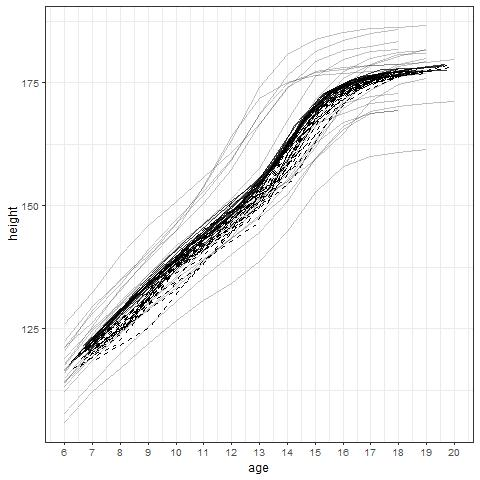

Figure 3.1: Observed curves along with the superimposed adjusted curves (via random effects) for the **sitar** and **bsitar** models. The observed curves are shown as solid light grey lines whereas the adjusted curves for the **sitar** model are displayed as solid black lines. The adjusted curves for the **bsitar** model are shown as dotted black lines.

```r
data_all_a <- data_all_a %>%
  dplyr::mutate(across(Curve, ~factor(.,
                                      levels=c("observed",
                                               "adjusted_sitar",
                                               "adjusted_bsitar"))))
data_all_alevs <- levels(data_all_a$Curve)

p <-
  data_all_a %>%
  dplyr::mutate(groupby = interaction(id, Curve) ) %>%
  ggplot(., aes(x = age))

p +
  geom_line(data = data_all_a %>%
              dplyr::filter(Curve==data_all_alevs[1]) %>%
              dplyr::mutate(groupby = interaction(id, Curve)),
            aes(x = age, y = height, group = groupby),
            linetype = linetypes[1],
             color = colours[1], linewidth = linewidths[1], alpha = alphas[1],
            show.legend = T) +
  geom_line(data = data_all_a %>%
              dplyr::filter(Curve==data_all_alevs[2]) %>%
              dplyr::mutate(groupby = interaction(id, Curve)),
            aes(x = age, y = height, group = groupby),
            linetype = linetypes[1],
             color = colours[1], linewidth = linewidths[1], alpha = alphas[3],
            show.legend = T) +
  geom_line(data = data_all_a %>%
              dplyr::filter(Curve==data_all_alevs[3]) %>%
              dplyr::mutate(groupby = interaction(id, Curve)),
            aes(x = age, y = height, group = groupby),
            linetype = linetypes[2],
             color = colours[1], linewidth = linewidths[1], alpha = alphas[4],
            show.legend = T) +
  scale_x_continuous(breaks = seq(xrange[1], xrange[2], 1), limits = xrange) +
  theme_grids1 + theme_legends1 +
  theme(legend.title=element_blank())
```

```r
# data_all_a %>%
#   dplyr::mutate(groupby = interaction(id, Curve) ) %>%
#   ggplot(., aes(x = age)) +
#   geom_line(aes(x = age, y = height, group = groupby,
#                 linetype = Curve),
#             color = colours[1], alpha = alphas[2], linewidth = linewidths[2],
#             show.legend = T) +
#   scale_x_continuous(breaks = seq(xrange[1], xrange[2], 1), limits = xrange) +
#   theme_grids1 + theme_legends1
```

# 4 Random effects (size, timing and intensity)

The effect of *SITAR* adjustment in individual curves via random effects is shown more clearly in Figure 4.1 which displays observed and adjusted curves for tallest and shortest individuals along with the population average (mean) curve. The corresponding estimates of random effects (size, timing and intensity) are provided in Tables 4.1 and 4.2. Note that intensity c, multiplied by 100, is a percentage. Results for both the models are very similar to each other. Results for the **sitar** model are presented below.

For a broader comparison among the **sitar** and **bsitar** models, random effects for the first ten individuals estimated are shown below in (Table 4.3 and (Table 4.4). The association (correlation) between random effects (across all individuals) is shown as a scatterplot in Figures 4.2 and 4.3, and the corresponding estimates are provided in Table 4.5 and Table 4.6. Results show that timing is negatively correlated with intensity indicating the early puberty is associated with faster growth.

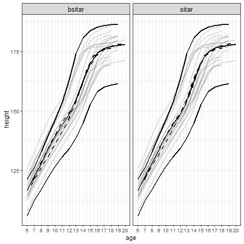

Figure 4.1: Observed and adjusted curve (via random effects) curves along with the population averag curves for **sitar** and **bsitar** models. The observed curves for all individuals are shown as solid light grey lines whereas curves for the tallest and shortest individuals are displayed using the solid black lines. The adjusted curves for the tallest and shortest individuals are shown as dotted black lines, and the population average curve is shown as solid black line

Table 4.1: Random effects for the tallest and shortest individual for the **sitar** model

| id | a | b | c |
| --- | --- | --- | --- |
| 234 | -15.07 | 0.07 | -0.16 |
| 237 | 7.47 | -0.98 | 0.28 |

a: Size (height); b: Timing (age at peak growth velocity, APGV); c: Intensity (peak growth velocity, AGV)

Table 4.2: Random effects for the tallest and shortest individual for the **bsitar** model

| id | a | b | c |
| --- | --- | --- | --- |
| 234 | -15.01 | 0.07 | -0.16 |
| 237 | 7.53 | -0.99 | 0.29 |

a: Size (height); b: Timing (age at peak growth velocity, APGV); c: Intensity (peak growth velocity, AGV)

Table 4.3: Random effects estimates for the first ten individuals (**sitar** model)

| id | a | b | c |
| --- | --- | --- | --- |
| 204 | 3.29 | 1.11 | -0.14 |
| 205 | -6.10 | -0.31 | 0.01 |
| 206 | 4.44 | 0.08 | 0.10 |
| 209 | 0.84 | 1.29 | -0.17 |
| 214 | 2.97 | 1.21 | -0.14 |
| 215 | -1.31 | -1.97 | 0.27 |
| 216 | 5.99 | -0.86 | 0.01 |
| 222 | -6.87 | 0.49 | -0.04 |
| 226 | 7.14 | -0.63 | 0.17 |
| 228 | 1.12 | -1.23 | 0.08 |

a: Size (height); b: Timing (age at peak growth velocity, APGV); c: Intensity (peak growth velocity, AGV)

Table 4.4: Random effects estimates for the first ten individuals (**bsitar** model)

| id | a | b | c |
| --- | --- | --- | --- |
| 204 | 3.36 | 1.11 | -0.14 |
| 205 | -6.06 | -0.32 | 0.01 |
| 206 | 4.52 | 0.08 | 0.10 |
| 209 | 0.96 | 1.29 | -0.16 |
| 214 | 3.11 | 1.22 | -0.14 |
| 215 | -1.24 | -1.97 | 0.27 |
| 216 | 5.97 | -0.87 | 0.00 |
| 222 | -6.75 | 0.49 | -0.04 |
| 226 | 7.18 | -0.63 | 0.17 |
| 228 | 1.17 | -1.24 | 0.08 |

```r
data_sitar_u_f <- plot(model_frequ, opt = 'u', returndata = T) %>%
  dplyr::relocate( all_of(idvar),  all_of(xvar), all_of(yvar)) %>%
  dplyr::mutate(Curve = 'u') %>% dplyr::mutate(Model = 'sitar')
data_sitar_a_f <- plot(model_frequ, opt = 'a', returndata = T) %>%
  dplyr::relocate( all_of(idvar),  all_of(xvar), all_of(yvar)) %>%
  dplyr::mutate(Curve = 'a') %>% dplyr::mutate(Model = 'sitar')
data_sitar_d_f <- plot(model_frequ, opt = 'd', returndata = T) %>%
  dplyr::relocate( all_of(idvar),  all_of(xvar), all_of(yvar)) %>%
  dplyr::mutate(Curve = 'd') %>% dplyr::mutate(Model = 'sitar')

data_sitar_uad_df12 <- data_sitar_u_f[, 1:2]
data_sitar_uad_df123 <- data_sitar_u_f[, 1:3]
data_bsitar_u_f <- plot_curves(model_bayes, opt = 'u', returndata = T, newdata = data_sitar_uad_df123, ipts = NULL, usesavedfuns = T, envir = globalenv())
data_bsitar_a_f <- plot_curves(model_bayes, opt = 'a', returndata = T, newdata = data_sitar_uad_df123, ipts = NULL, usesavedfuns = T, envir = globalenv())
data_bsitar_d_f <- plot_curves(model_bayes, opt = 'd', returndata = T, newdata = data_sitar_uad_df12, ipts = NULL, usesavedfuns = T, envir = globalenv())

data_bsitar_u_f <- data_bsitar_u_f %>% dplyr::rename(!!yvar := yvar) %>% dplyr::select(all_of(colnames(data_sitar_uad_df123)))
data_bsitar_a_f <- data_bsitar_a_f %>% dplyr::rename(!!yvar := yvar) %>% dplyr::select(all_of(colnames(data_sitar_uad_df123)))
data_bsitar_d_f <- data_bsitar_d_f %>% dplyr::rename(!!yvar := 'Estimate') %>% dplyr::select(all_of(colnames(data_sitar_uad_df123)))

data_bsitar_u_f <- data_bsitar_u_f %>% dplyr::mutate(Curve = 'u') %>% dplyr::mutate(Model = 'bsitar')
data_bsitar_a_f <- data_bsitar_a_f %>% dplyr::mutate(Curve = 'a') %>% dplyr::mutate(Model = 'bsitar')
data_bsitar_d_f <- data_bsitar_d_f %>% dplyr::mutate(Curve = 'd') %>% dplyr::mutate(Model = 'bsitar')

data_sitar_uad_f <- data_sitar_u_f %>%
  dplyr::bind_rows(., data_sitar_a_f) %>%
  dplyr::bind_rows(., data_sitar_d_f)

data_bsitar_uad_f <- data_bsitar_u_f %>%
  dplyr::bind_rows(., data_bsitar_a_f) %>%
  dplyr::bind_rows(., data_bsitar_d_f)


data_sitar_uad_f <- data_sitar_uad_f %>%
  dplyr::mutate(across(Curve, ~factor(.,
                                      levels=c("u",
                                               "a",
                                               "d"))))

data_sitar_uad_f <- data_sitar_uad_f %>%
  dplyr::mutate(Curve = dplyr::recode(Curve, u = "unadj",
                          a = "adj",
                          d = "pop.avg"))



data_bsitar_uad_f <- data_bsitar_uad_f %>%
  dplyr::mutate(across(Curve, ~factor(.,
                                      levels=c("u",
                                               "a",
                                               "d"))))

data_bsitar_uad_f <- data_bsitar_uad_f %>%
  dplyr::mutate(Curve = dplyr::recode(Curve, u = "unadj",
                                      a = "adj",
                                      d = "pop.avg"))


data_sitar_bsitar_uad_f <- data_sitar_uad_f %>%
  dplyr::bind_rows(., data_bsitar_uad_f)

data_all_alevs <- levels(data_sitar_uad_f$Curve)


which_uad_f <- data_sitar_bsitar_uad_f # data_sitar_uad_f


p <-
  which_uad_f %>%
  dplyr::mutate(groupby = interaction(.data[[idvar]], Curve) ) %>%
  ggplot(., aes(x = .data[[xvar]]))

p +
  geom_line(data = which_uad_f %>%
              dplyr::filter(Curve==data_all_alevs[1]) %>%
              dplyr::mutate(groupby = interaction(.data[[idvar]], Curve)),
            aes(x = .data[[xvar]], y = .data[[yvar]], group = groupby),
            linetype = linetypes[1],
           color = colours[1], linewidth = linewidths[1], alpha = alphas[1],
            show.legend = T) +
  geom_line(data = which_uad_f %>%
              dplyr::filter(Curve==data_all_alevs[1]) %>%
              dplyr::filter(.data[[idvar]] %in% ranef_id_max_min[1]) %>%
              dplyr::mutate(Curve =
                              paste0(Curve, ".", idvar, ".", ranef_id_max_min[1])) %>%
              dplyr::mutate(groupby = interaction(.data[[idvar]], Curve)),
            aes(x = .data[[xvar]], y = .data[[yvar]], group = groupby),
            linetype = linetypes[1],
            color = colours[1], linewidth = linewidths[2], alpha = alphas[4],
              show.legend = T) +
  geom_line(data = which_uad_f %>%
              dplyr::filter(Curve==data_all_alevs[2]) %>%
              dplyr::filter(.data[[idvar]] %in% ranef_id_max_min[1]) %>%
              dplyr::mutate(Curve =
                              paste0(Curve, ".", idvar, ".", ranef_id_max_min[1])) %>%
              dplyr::mutate(groupby = interaction(.data[[idvar]], Curve)),
            aes(x = .data[[xvar]], y = .data[[yvar]], group = groupby),
            linetype = linetypes[2],
            color = colours[1], linewidth = linewidths[2], alpha = alphas[4],
            show.legend = T) +
  geom_line(data = which_uad_f %>%
              dplyr::filter(Curve==data_all_alevs[1]) %>%
              dplyr::filter(.data[[idvar]] %in% ranef_id_max_min[2]) %>%
              dplyr::mutate(Curve =
                              paste0(Curve, ".", idvar, ".", ranef_id_max_min[2]) ) %>%
              dplyr::mutate(groupby = interaction(.data[[idvar]], Curve)),
            aes(x = .data[[xvar]], y = .data[[yvar]], group = groupby),
            linetype = linetypes[1],
            color = colours[1], linewidth = linewidths[2], alpha = alphas[4],
            show.legend = T) +
  geom_line(data = which_uad_f %>%
              dplyr::filter(Curve==data_all_alevs[2]) %>%
              dplyr::filter(.data[[idvar]] %in% ranef_id_max_min[2]) %>%
              dplyr::mutate(Curve =
                              paste0(Curve, ".", idvar, ".", ranef_id_max_min[2]) ) %>%
              dplyr::mutate(groupby = interaction(.data[[idvar]], Curve)),
            aes(x = .data[[xvar]], y = .data[[yvar]], group = groupby),
            linetype = linetypes[2],
            color = colours[1], linewidth = linewidths[2], alpha = alphas[4],
            show.legend = T) +
  geom_line(data = which_uad_f %>%
              dplyr::filter(Curve==data_all_alevs[3]) %>%
              dplyr::mutate(groupby = interaction(Curve)),
            aes(x = .data[[xvar]], y = .data[[yvar]], group = groupby),
            linetype = linetypes[1],
             color = colours[1], linewidth = linewidths[2], alpha = alphas[4],
            show.legend = T) +
  facet_wrap(~Model) +
  scale_x_continuous(breaks = seq(xrange[1], xrange[2], 1), limits = xrange) +
  theme_grids1 + theme_legends1 +
  theme(strip.text.x = element_text(size = 12, colour = "black", angle = 0)) +
  theme(legend.title=element_blank())
```

a: Size (height); b: Timing (age at peak growth velocity, APGV); c: Intensity (peak growth velocity, AGV)

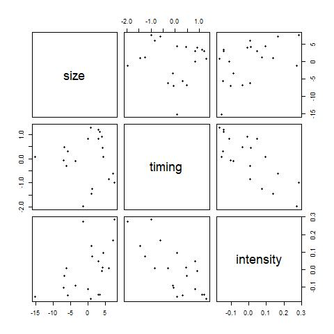

Figure 4.2: Correlation scatterplot of random effects for the **sitar** model

```r
pairs(nlme::ranef(model_frequ), labels = c('size', 'timing', 'intensity'), pch=20)
```

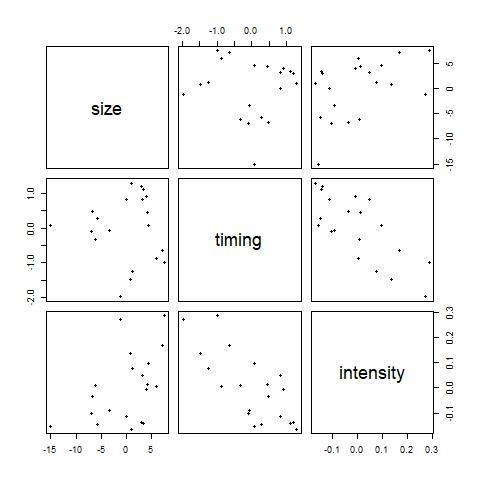

Figure 4.3: Correlation scatterplot of random effects for the **bsitar** model

Table 4.5: Correlation estimates for the random effects (**sitar** model)

| a | b | c |
| --- | --- | --- |
| 1.00 | -0.04 | 0.47 |
| -0.04 | 1.00 | -0.75 |
| 0.47 | -0.75 | 1.00 |

a: Size (height); b: Timing (age at peak growth velocity, APGV); c: Intensity (peak growth velocity, AGV)

Table 4.6: Correlation estimates for the random effects (**bsitar** model)

| a | b | c |
| --- | --- | --- |
| 1.00 | -0.03 | 0.47 |
| -0.03 | 1.00 | -0.75 |
| 0.47 | -0.75 | 1.00 |

```r
pairs(bfh1_ranef, labels = c('size', 'timing', 'intensity'), pch=20)
```

a: Size (height); b: Timing (age at peak growth velocity, APGV); c: Intensity (peak growth velocity, AGV)

# 5 Growth curves (distance and velocity)

## 5.1 Population average (mean) distance and velocity curves

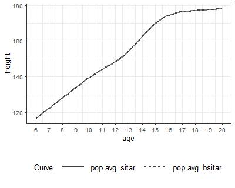

Figure 5.1: Population average distance curves (increase in size) for the **sitar** and **bsitar** models

```r
data_sitar_dx2  <- plot(model_frequ, opt = 'd', xlim = sitar::xaxsd(), ylim = sitar::yaxsd(), returndata = T)
data_sitar_dfx2 <- data_sitar_dx2 %>% data.frame()
data_bsitar_dx2 <- plot_curves(model_bayes, opt = 'd', returndata = T, newdata = data_sitar_dfx2, ipts = NULL, usesavedfuns = T, envir = globalenv()) %>%
  dplyr::rename(distance = Estimate) %>%
  dplyr::select(-dplyr::all_of(c('distance', 'Est.Error',  'Q2.5', 'Q97.5')))
data_all_ad <- data_all_a %>%
  dplyr::bind_rows(., data_sitar_dx2 %>% dplyr::relocate(all_of(colnames(data))) %>%
                     dplyr::mutate(Curve = 'pop.avg_sitar')) %>%
  dplyr::bind_rows(., data_bsitar_dx2 %>% dplyr::relocate(all_of(colnames(data))) %>%
                     dplyr::mutate(Curve = 'pop.avg_bsitar')) %>%
  dplyr::mutate(Curve = as.factor(Curve))


data_all_ad <- data_all_ad %>%
  dplyr::mutate(across(Curve, ~factor(.,
                                      levels=c("observed",
                                               "adjusted_sitar",
                                               "adjusted_bsitar",
                                               "pop.avg_sitar",
                                               "pop.avg_bsitar" ))))

data_all_alevs <- levels(data_all_ad$Curve)

p <-
  data_all_ad %>%
  dplyr::mutate(groupby = interaction(id, Curve)) %>%
  ggplot(., aes(x = age))
# p +
#   geom_line(data = data_all_ad %>% dplyr::filter(Curve==data_all_alevs[1]) %>%
#               dplyr::mutate(groupby = interaction(id, Curve)),
#               aes(x = age, y = height, group = groupby),
#             linetype = 1, color = colours[1], , linewidth = linewidths[2],
#             alpha = alphas[2], show.legend = F) +
#   geom_line(data = data_all_ad %>% dplyr::filter(Curve==data_all_alevs[2]) %>%
#               dplyr::mutate(groupby = interaction(id, Curve)),
#             aes(x = age, y = height, group = groupby),
#             linetype = 1, color = colours[1], , linewidth = linewidths[2],
#             alpha = alphas[2], show.legend = F) +
#   geom_line(data = data_all_ad %>% dplyr::filter(Curve==data_all_alevs[3]) %>%
#               dplyr::mutate(groupby = interaction(id, Curve)),
#             aes(x = age, y = height, group = groupby),
#             linetype = 1, color = colours[1], , linewidth = linewidths[2],
#             alpha = alphas[2], show.legend = F) +
#   geom_line(data = data_all_ad %>% dplyr::filter(Curve==data_all_alevs[4]) %>%
#               dplyr::mutate(groupby = interaction(id, Curve)),
#             aes(x = age, y = height, group = groupby),
#             linetype = 1, color = colours[1], , linewidth = linewidths[2],
#             alpha = alphas[2], show.legend = F) +
#   geom_line(data = data_all_ad %>% dplyr::filter(Curve==data_all_alevs[5]) %>%
#               dplyr::mutate(groupby = interaction(id, Curve)),
#             aes(x = age, y = height, group = groupby),
#             linetype = 1, color = colours[1], , linewidth = linewidths[2],
#             alpha = alphas[2], show.legend = F) +
#   facet_wrap(~Curve) +
#   scale_x_continuous(breaks = seq(xrange[1], xrange[2], 1), limits = xrange) +
#   theme_grids1 + theme_legends1

p +
  geom_line(data = data_all_ad %>% dplyr::filter(Curve==data_all_alevs[4]) %>%
              dplyr::mutate(groupby = interaction(id, Curve)),
            aes(x = age, y = height, group = groupby, linetype = Curve),
            color = colours[1], linewidth = linewidths[2],
            alpha = alphas[2], show.legend = T) +
  geom_line(data = data_all_ad %>% dplyr::filter(Curve==data_all_alevs[5]) %>%
              dplyr::mutate(groupby = interaction(id, Curve)),
            aes(x = age, y = height, group = groupby, linetype = Curve),
            color = colours[1], linewidth = linewidths[2],
            alpha = alphas[2], show.legend = T) +
  scale_x_continuous(breaks = seq(xrange[1], xrange[2], 1), limits = xrange) +
  theme_grids1 + theme_legends1
```

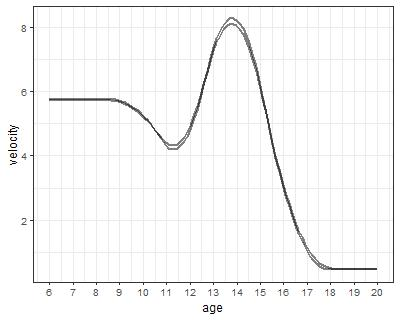

Figure 5.2: Population average velocity curves (change in growth rate) for the **sitar** and **bsitar** models

```r
data_all_dv %>%
  dplyr::mutate(groupby = interaction(id, Model) ) %>%
  ggplot(., aes(x = age)) +
  geom_line(aes(x = age, y = velocity, group = groupby),
            color = colours[1], alpha = alphas[2], linewidth = linewidths[2],
            show.legend = TRUE) +
  scale_x_continuous(breaks = seq(xrange[1], xrange[2], 1), limits = xrange) +
  theme_grids1 + theme_legends1
```

## 5.2 Individual specific distance and velocity curves

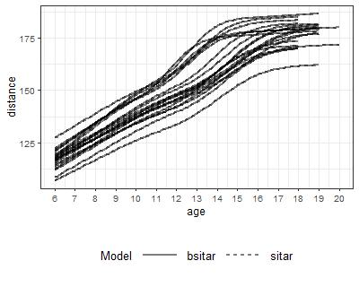

Figure 5.3: Individual specific distance curves (increase in size) for the **sitar** and **bsitar** models

```r
data_all_DV %>%
  dplyr::mutate(groupby = interaction(id, Model) ) %>%
  ggplot(., aes(x = age)) +
  geom_line(aes(x = age, y = distance, group = groupby,
                linetype = Model),
            color = colours[1], alpha = alphas[2], linewidth = linewidths[2],
            show.legend = T) +
  scale_x_continuous(breaks = seq(xrange[1], xrange[2], 1), limits = xrange) +
  theme_grids1 + theme_legends1
```

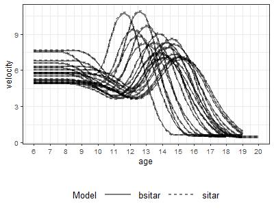

Figure 5.4: Individual specific velocity curves (change in growth rate) for the **sitar** and **bsitar** models

```r
data_all_DV %>%
  dplyr::mutate(groupby = interaction(id, Model) ) %>%
  ggplot(., aes(x = age)) +
  geom_line(aes(x = age, y = velocity, group = groupby,
                linetype = Model),
            color = colours[1], alpha = alphas[2], linewidth = linewidths[2],
            show.legend = T) +
  scale_x_continuous(breaks = seq(xrange[1], xrange[2], 1), limits = xrange) +
  theme_grids1 + theme_legends1
```

# 6 Growth parameters (timing and intensity)

## 6.1 Population average (mean) estimates

As velocity curves estimated by the **sitar** and **bsitar** models are very similar to each other (Figure 5.2), it is not surprising that both models provide almost identical estimates for the timing (i.e., age at peak growth velocity, APGV) and the intensity (i.e.,peak growth velocity, PGV) of the growth spurt (see Table 6.1).

Table 6.1: Population average timing and intensity estimates for the **sitar** and **bsitar** models

| Parameter | bsitar | sitar |
| --- | --- | --- |
| APGV | 13.78 | 13.80 |
| PGV | 8.09 | 8.26 |

APGV: age at peak growth velocity; PGV: peak growth velocity

## 6.2 Individual specific estimates

Like population average, both **sitar** and **bsitar** models provide very similar estimates for the timing (APGV) and the intensity (PGV) of the growth spurt (see Table 6.2) and (Table 6.3).

Table 6.2: Individual specific timing and intensity estimates for the first ten individuals (**sitar** model)

| id | APGV | PGV |
| --- | --- | --- |
| 204 | 15.05 | 7.17 |
| 205 | 13.48 | 8.33 |
| 206 | 13.79 | 9.10 |
| 209 | 15.25 | 7.00 |
| 214 | 15.15 | 7.17 |
| 215 | 11.60 | 10.86 |
| 216 | 12.93 | 8.32 |
| 222 | 14.32 | 7.95 |
| 226 | 13.03 | 9.76 |
| 228 | 12.49 | 8.92 |

APGV: age at peak growth velocity; PGV: peak growth velocity

Table 6.3: Individual specific timing and intensity estimates for the first ten individuals (**bsitar** model)

| id | APGV | PGV |
| --- | --- | --- |
| 204 | 15.05 | 7.08 |
| 205 | 13.47 | 8.24 |
| 206 | 13.80 | 9.01 |
| 209 | 15.26 | 6.91 |
| 214 | 15.15 | 7.10 |
| 215 | 11.61 | 10.73 |
| 216 | 12.92 | 8.20 |
| 222 | 14.32 | 7.87 |
| 226 | 13.03 | 9.65 |
| 228 | 12.49 | 8.83 |

APGV: age at peak growth velocity; PGV: peak growth velocity

# 7 References

Cole, T. (2022). *Sitar: Super imposition by translation and rotation growth curve analysis*. https://CRAN.R-project.org/package=sitar

Cole, T. J., Donaldson, M. D. C., & Ben-Shlomo, Y. (2010). SITAR—a useful instrument for growth curve analysis. *International Journal of Epidemiology*, *39*(6), 1558–1566. https://doi.org/10.1093/ije/dyq115

Sandhu, S. (2023). *Bsitar: Bayesian super imposition by translation and rotation growth curve analysis*. https://CRAN.R-project.org/package=bsitar